# Relatório GEOLV

CEPESPData

## 1. Análise Descritiva - GeoLV

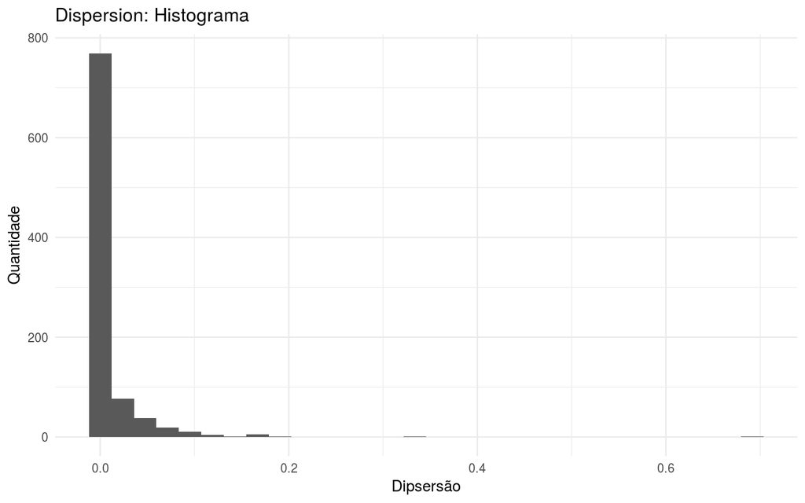

A distribuição da variável *dispersion* é bastante concentrada do lado esquerdo do gráfico. Algumas poucas exceções de valores mais altos. Talvez seja interessante considerar alguma transformação dessa variável a fim de melhor avaliar a qualidade dos resultados.

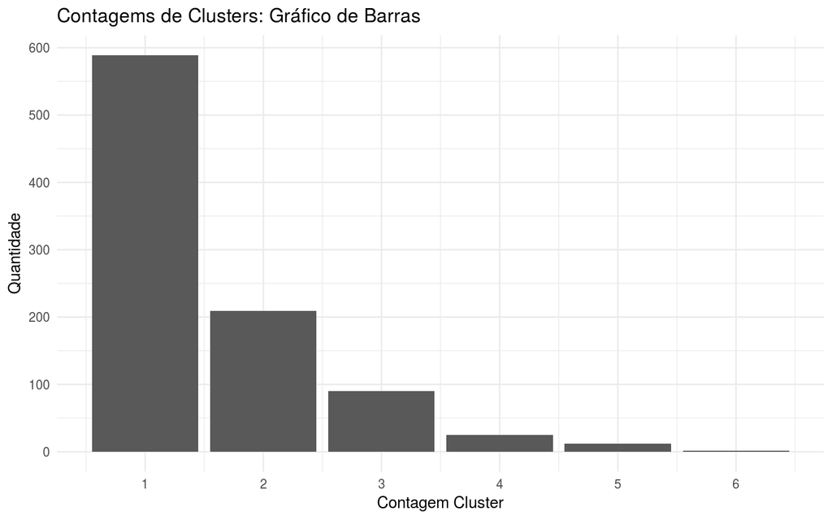

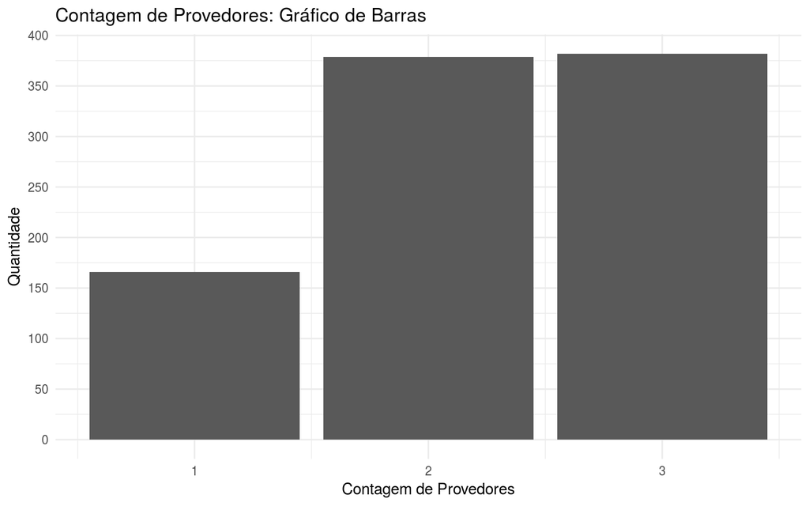

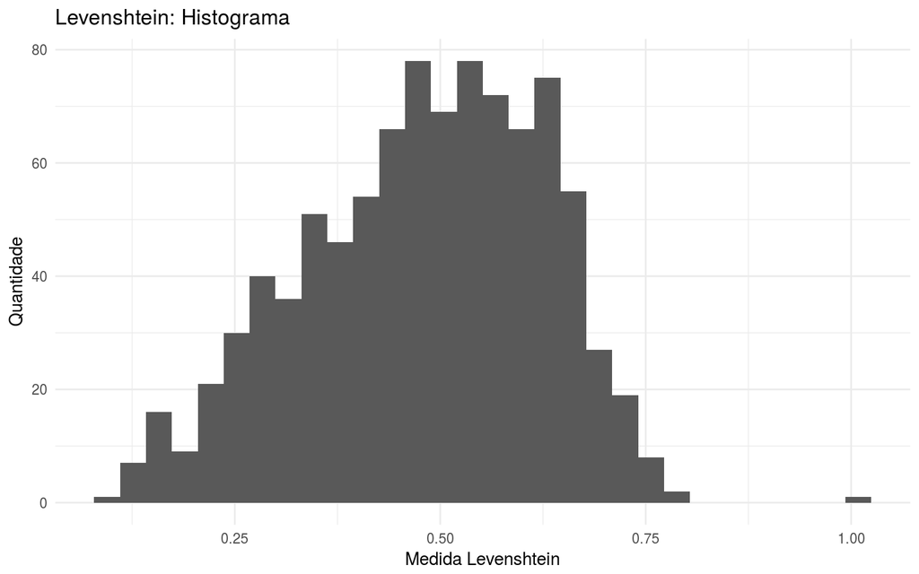

| Estatística | Mínimo | 1º Quartil | Mediana | 3º Quartil | Máximo | Média |
| --- | --- | --- | --- | --- | --- | --- |
| Dispersion | 0.00000 | 0.00003 | 0.00015 | 0.00372 | 0.69169 | 0.01006 |
| Nº Clusters | 1.00000 | 1.00000 | 1.00000 | 2.00000 | 6.00000 | 1.56311 |
| Nº Provedores | 1.00000 | 2.00000 | 2.00000 | 3.00000 | 3.00000 | 2.23301 |
| Levenshtein | 0.08571 | 0.38209 | 0.50000 | 0.59375 | 1.00000 | 0.48042 |

### 1.1. Descritiva por Município

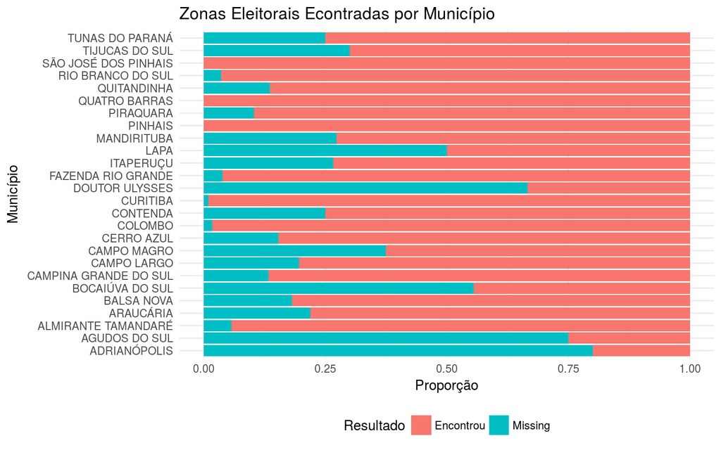

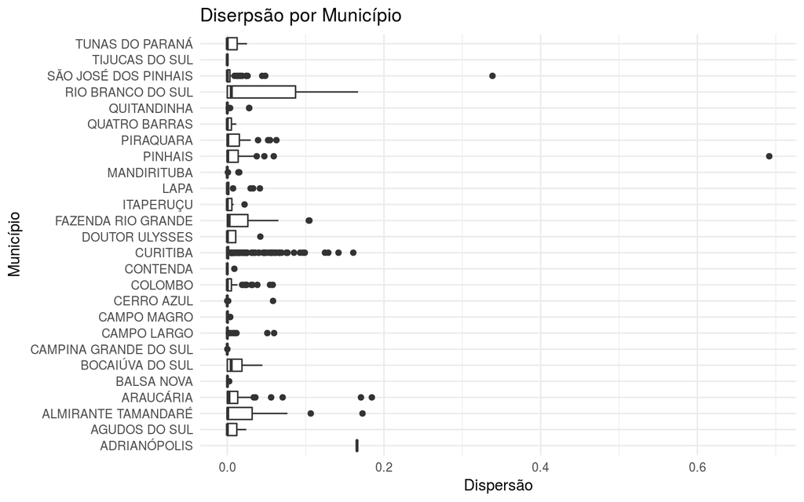

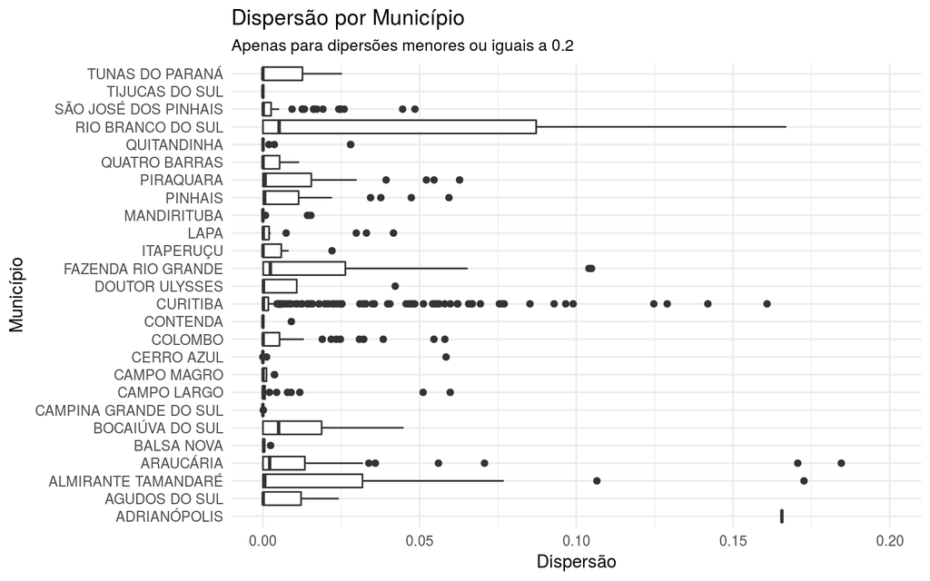

A fim de melhor visualizar a difereça entre as cidades, neste imagem limitei o gráfico para o intervalo de dispersão (0, 0.2). Aparentemente temos dois padrões de distribuição. De um lado, cidades que ficaram bem próximas do 0 (ex. Curitiba, Campina Grande do Sul, Lapa) e de cidades que com um intervalo um pouco maior (Agudos do Sul, etc).

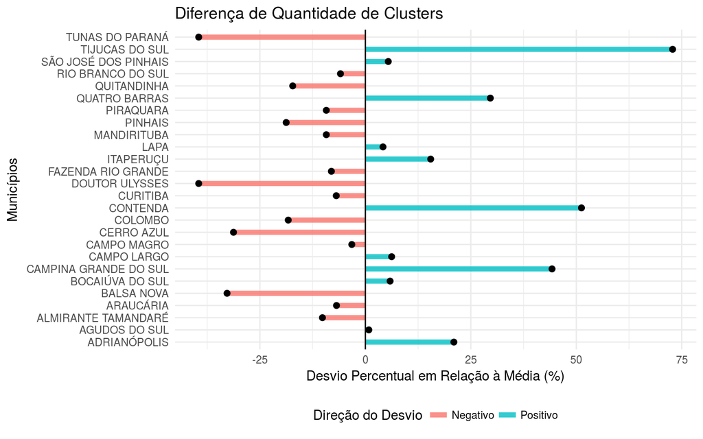

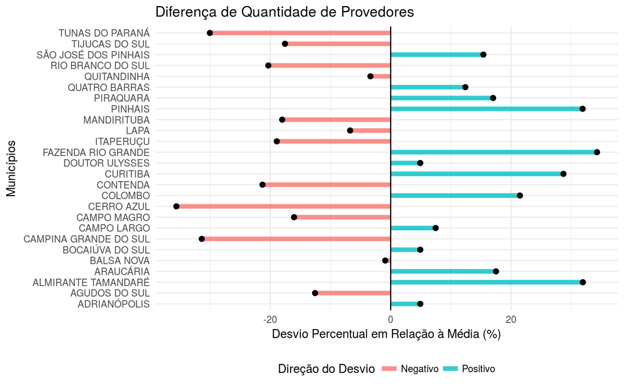

## 2. Zonas Verificadas Manualmente

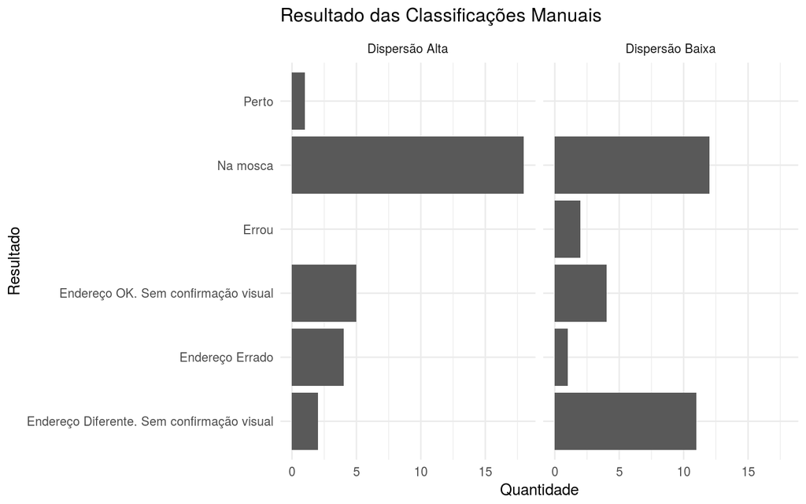

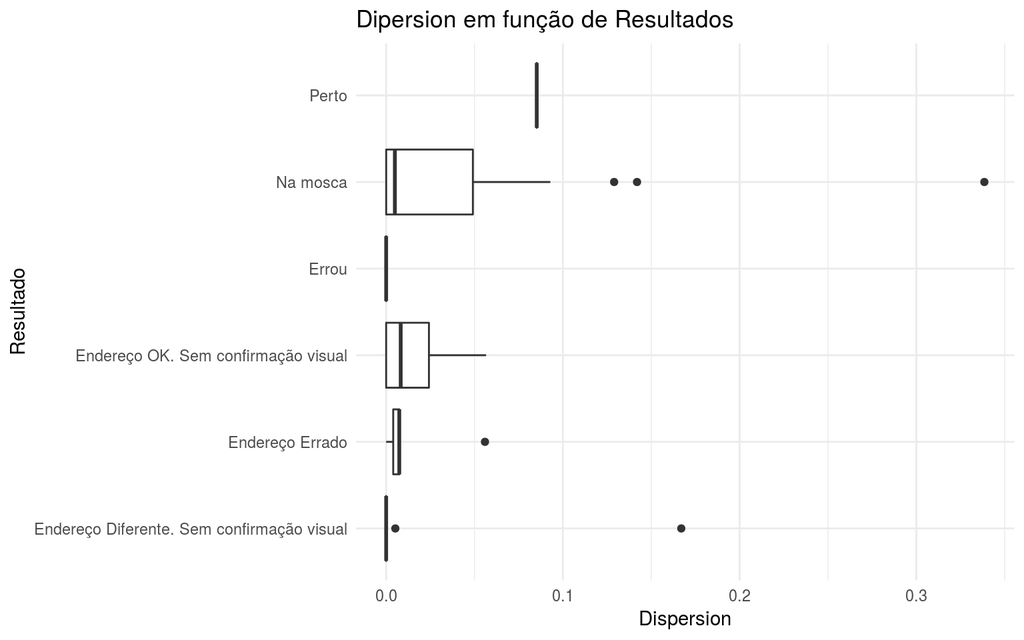

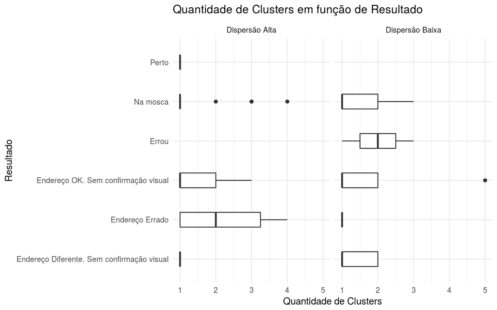

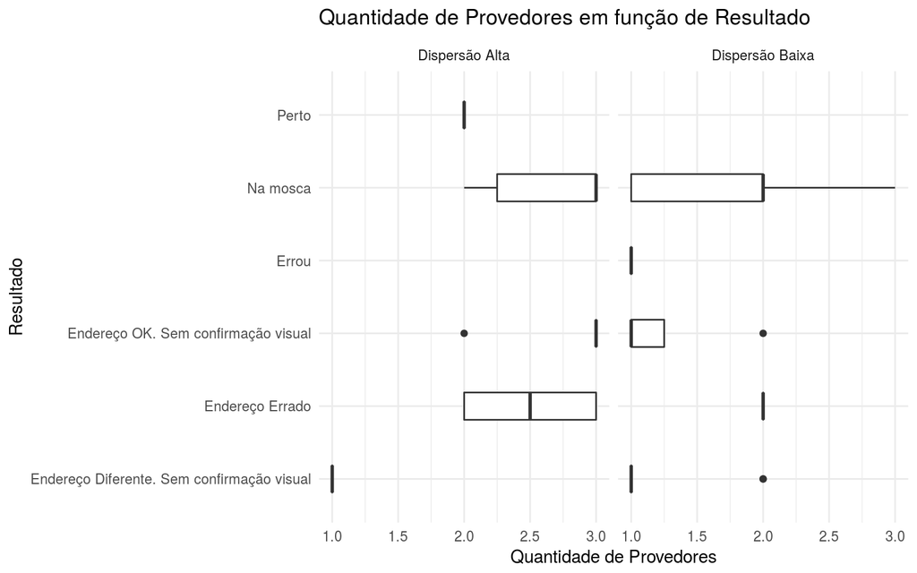

- Legenda:
  - Na mosca: Endereço exatato do local de votação.
  - Perto: Endereço obtido foi próximo ao local de votação.
  - Errou: Endereço obtido foi longe do local de votação.
  - Endereço OK. Sem confirmação visual: Endereço obtido equivale ao fornecido, mas não foi possível confirmar visualmente o resultado (*Street View* indisponível ou Local não encontrado).
  - Endereço Diferente. Sem confirmação visual: Endereço obtido não equivale ao fornecido e não foi possível confirmar visualmente o resultado (*Street View* indisponível ou Local não encontrado).
  - Endereço Errado: Endereço fornecido não condiz com o local de votação.

## 3. Validação Externa

Nesta seção, o objetivo foi averiguar os pontos obtidos em contraste com fontes externas. Dado que a prefeitura de Curitiba possui as zonas de votação geolocalizadas, foi possível averiguar a distâncias entre essas inforçaões da prefeitura e os fornecidos pelo GeoLV nas 414 zonas eleitorais do município.

Em primeiro lugar, temos as distãncias entre os pontos. A princípio, grande parte ficou abaixo dos 100 metros de distância. Ainda assim, agulmas observações obtiveram uma distância relativamente alta, maior do 1000 m de distância.

Estatísticas Descritivas da Distância

| Mínimo | 1º Quartil | Mediana | Média | 3º Quartil | Máximo |
| --- | --- | --- | --- | --- | --- |
| 0.7739176 | 22.30476 | 38.92717 | 131.7944 | 88.97802 | 9640.851 |

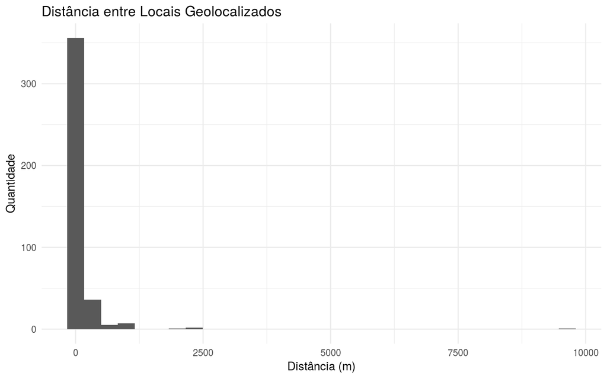

Na tabela seguinte, é possível ver quais foram as observações com mais do que 1000 m de distância.

Locais de Votação com Distância maior do que 1000 m

| Nº Obs | Município | Local de Votação | Nº Zona | Nº Local Votação | Lon | Lat | Dist (m) |
| --- | --- | --- | --- | --- | --- | --- | --- |
| 732 | CURITIBA | COLEGIO ESTADUAL PROFESSOR ALGACYR MUNHOZ MAEDER | 2 | 1899 | -49.21057 | -25.39564 | 1042.450 |
| NA | Curitiba | COLEGIO ESTADUAL PROFESSOR ALGACYR MUNHOZ MAEDER | 2 | 1899 | -49.20666 | -25.40435 | 1042.450 |
| 768 | CURITIBA | ESCOLA MUNICIPAL ELZA LERNER | 3 | 1589 | -49.22544 | -25.44483 | 2190.503 |
| NA | Curitiba | ESCOLA MUNICIPAL ELZA LERNER | 3 | 1589 | -49.21461 | -25.46198 | 2190.503 |
| 776 | CURITIBA | ESCOLA MUNICIPAL RACHEL MADER GONÇALVES | 3 | 2062 | -49.22112 | -25.49896 | 2489.532 |
| NA | Curitiba | ESCOLA MUNICIPAL RACHEL MADER GONÇALVES | 3 | 2062 | -49.20022 | -25.48691 | 2489.532 |
| 786 | CURITIBA | COLEGIO ESTADUAL PEDRO MACEDO | 4 | 1449 | -49.29260 | -25.47688 | 1081.352 |
| NA | Curitiba | COLEGIO ESTADUAL PEDRO MACEDO | 4 | 1449 | -49.29307 | -25.46713 | 1081.352 |
| 447 | CURITIBA | CEI FRANCISCO FRISCHMANN | 145 | 1538 | -49.28270 | -25.51482 | 1955.357 |
| NA | Curitiba | CEI FRANCISCO FRISCHMANN | 145 | 1538 | -49.26809 | -25.52648 | 1955.357 |
| 539 | CURITIBA | ESCOLA MUNICIPAL PRO-MORAR BARIGUI-I | 175 | 1015 | -49.33435 | -25.50416 | 1025.403 |
| NA | Curitiba | ESCOLA MUNICIPAL PRO-MORAR BARIGUI-I | 175 | 1015 | -49.33549 | -25.49496 | 1025.403 |
| 542 | CURITIBA | COLÉGIO ESTADUAL PROF. ALCYONE MORAES DE CASTRO VELLOZO | 175 | 1040 | -49.24783 | -25.46009 | 9640.851 |
| NA | Curitiba | COLÉGIO ESTADUAL PROF. ALCYONE MORAES DE CASTRO VELLOZO | 175 | 1040 | -49.32424 | -25.51267 | 9640.851 |
| 588 | CURITIBA | ESCOLA MUNICIPAL ITACELINA BITTENCOURT | 176 | 1066 | -49.27982 | -25.46180 | 1091.425 |
| NA | Curitiba | ESCOLA MUNICIPAL ITACELINA BITTENCOURT | 176 | 1066 | -49.27535 | -25.47078 | 1091.425 |

[interactive chart not shown]

## 4. Conclusões

### 4.2. Verificação Manual

O teste manual das coordenadas obtidas pelo GeoLV levou a alguns apontamentos:

- Observações no centro de cidades tendem a ser mais confiáveis, enquanto locais de votação nas periferias ou em zonas rurais tendem a ser menos confiáveis e imprecisos. Isso é esperado, mas vale tomar cuidado ainda assim.
- Em endereços rurais ou mais distantes do centro, um dos maiores problemas está nos enfereços dos locais do votação. A falta do **número da rua** ou um **endereço de rodovia** (BR 111, km 20, por exemplo) tendem a ser mais imprecisos.
  - Solução Proposta: para endereços com uma dessas características seria interessante tentar geolocalizá-los novamente com o **nome** do local de votação. Em tentativas manuais, o resultado pareceu mais promissos.
- Endereços com número muito grande podem conter marcores (`.`, `,`) que confundem a API dos provedores. Por exemplo, ao fornecer Rua Fictícia 123.000 (cento e vinte e três mil), a API entende como 123 (cento e vinte e três).